# Lab 7 Output

[output not shown]

Log  
Log - Log - August 16, 2018

NEW FILE.  
DATASET NAME DataSet1 WINDOW=FRONT.  
GET  
FILE='C:\Users\Heather\OneDrive - Brock University\Masters\TA\BIOL3P96\2019\Lab 7\SPSS files\anorexia family therapy.sav'.  
>Warning # 5281. Command name: GET FILE  
>SPSS Statistics is running in Unicode encoding mode. This file is encoded in  
>a locale-specific (code page) encoding. The defined width of any string  
>variables are automatically tripled in order to avoid possible data loss. You  
>can use ALTER TYPE to set the width of string variables to the width of the  
>longest observed value for each string variable.  
DATASET NAME DataSet2 WINDOW=FRONT.  
DATASET CLOSE DataSet1.  
T-TEST PAIRS=BEFORE WITH AFTER (PAIRED)  
/CRITERIA=CI(.9500)  
/MISSING=ANALYSIS.

T-Test  
T-Test - Paired Samples Statistics - August 16, 2018

Paired Samples StatisticsPaired Samples Statistics, table, 1 levels of column headers and 2 levels of row headers, table with 6 columns and 4 rows

|  |  | Mean | N | Std. Deviation | Std. Error Mean |
| --- | --- | --- | --- | --- | --- |
| Pair 1 | BEFORE | 83.229 | 17 | 5.0167 | 1.2167 |
|  | AFTER | 90.494 | 17 | 8.4751 | 2.0555 |

T-Test  
T-Test - Paired Samples Correlations - August 16, 2018

Paired Samples CorrelationsPaired Samples Correlations, table, 1 levels of column headers and 2 levels of row headers, table with 5 columns and 3 rows

|  |  | N | Correlation | Sig. |
| --- | --- | --- | --- | --- |
| Pair 1 | BEFORE & AFTER | 17 | .538 | .026 |

T-Test  
T-Test - Paired Samples Test - August 16, 2018

Paired Samples TestPaired Samples Test, table, 3 levels of column headers and 2 levels of row headers, table with 10 columns and 5 rows

|  |  | Paired Differences |  |  |  |  | t | df | Sig. (2-tailed) |  |  |  |
| --- | --- | --- | --- | --- | --- | --- | --- | --- | --- | --- | --- | --- |
|  |  | Mean | Std. Deviation | Std. Error Mean | 95% Confidence Interval of the Difference |  |  |  |  |  |  |  |
|  |  |  |  |  | Lower | Upper |  |  |  |  |  |  |
| Pair 1 | BEFORE - AFTER | -7.2647 | 7.1574 | 1.7359 | -10.9447 | -3.5847 |  |  |  | -4.185 | 16 | .001 |

Log  
Log - Log - August 16, 2018

T-TEST  
/TESTVAL=0  
/MISSING=ANALYSIS  
/VARIABLES=GAIN  
/CRITERIA=CI(.95).

T-Test  
T-Test - One-Sample Statistics - August 16, 2018

One-Sample StatisticsOne-Sample Statistics, table, 1 levels of column headers and 1 levels of row headers, table with 5 columns and 3 rows

|  | N | Mean | Std. Deviation | Std. Error Mean |
| --- | --- | --- | --- | --- |
| GAIN | 17 | 7.265 | 7.1574 | 1.7359 |

T-Test  
T-Test - One-Sample Test - August 16, 2018

One-Sample TestOne-Sample Test, table, 3 levels of column headers and 1 levels of row headers, table with 7 columns and 5 rows

|  | Test Value = 0 |  |  |  |  |  |
| --- | --- | --- | --- | --- | --- | --- |
|  | t | df | Sig. (2-tailed) | Mean Difference | 95% Confidence Interval of the Difference |  |
|  |  |  |  |  | Lower | Upper |
| GAIN | 4.185 | 16 | .001 | 7.2647 | 3.585 | 10.945 |

Log  
Log - Log - August 16, 2018

GET  
FILE='C:\Users\Heather\OneDrive - Brock University\Masters\TA\BIOL3P96\2019\Lab 7\SPSS files\ataxia.sav'.  
>Warning # 5281. Command name: GET FILE  
>SPSS Statistics is running in Unicode encoding mode. This file is encoded in  
>a locale-specific (code page) encoding. The defined width of any string  
>variables are automatically tripled in order to avoid possible data loss. You  
>can use ALTER TYPE to set the width of string variables to the width of the  
>longest observed value for each string variable.  
DATASET NAME DataSet3 WINDOW=FRONT.  
T-TEST GROUPS=treatment(0 1)  
/MISSING=ANALYSIS  
/VARIABLES=lifespan  
/CRITERIA=CI(.95).

T-Test  
T-Test - Active Dataset - August 16, 2018

[DataSet3] C:\Users\Heather\OneDrive - Brock University\Masters\TA\BIOL3P96\2019\Lab 7\SPSS files\ataxia.sav

T-Test  
T-Test - Group Statistics - August 16, 2018

Group StatisticsGroup Statistics, table, 1 levels of column headers and 2 levels of row headers, table with 6 columns and 4 rows

|  | treatment | N | Mean | Std. Deviation | Std. Error Mean |
| --- | --- | --- | --- | --- | --- |
| lifespan | No Exercise | 6 | 267.33 | 14.976 | 6.114 |
|  | Exercise | 6 | 310.00 | 29.570 | 12.072 |

T-Test  
T-Test - Independent Samples Test - August 16, 2018

Independent Samples TestIndependent Samples Test, table, 3 levels of column headers and 2 levels of row headers, table with 11 columns and 6 rows

|  |  | Levene's Test for Equality of Variances |  | t-test for Equality of Means |  |  |  |  |  |  |
| --- | --- | --- | --- | --- | --- | --- | --- | --- | --- | --- |
|  |  | F | Sig. | t | df | Sig. (2-tailed) | Mean Difference | Std. Error Difference | 95% Confidence Interval of the Difference |  |
|  |  |  |  |  |  |  |  |  | Lower | Upper |
| lifespan | Equal variances assumed | 1.900 | .198 | -3.153 | 10 | .010 | -42.667 | 13.532 | -72.818 | -12.516 |
|  | Equal variances not assumed |  |  | -3.153 | 7.407 | .015 | -42.667 | 13.532 | -74.312 | -11.022 |

Log  
Log - Log - August 16, 2018

GET  
FILE='C:\Users\Heather\OneDrive - Brock University\Masters\TA\BIOL3P96\2019\Lab 7\SPSS files\Homophobia.sav'.  
DATASET NAME DataSet4 WINDOW=FRONT.  
T-TEST GROUPS=Group(1 2)  
/MISSING=ANALYSIS  
/VARIABLES=Arousal  
/CRITERIA=CI(.95).

T-Test  
T-Test - Active Dataset - August 16, 2018

[DataSet4] C:\Users\Heather\OneDrive - Brock University\Masters\TA\BIOL3P96\2019\Lab 7\SPSS files\Homophobia.sav

T-Test  
T-Test - Group Statistics - August 16, 2018

Group StatisticsGroup Statistics, table, 1 levels of column headers and 2 levels of row headers, table with 6 columns and 4 rows

|  | Group | N | Mean | Std. Deviation | Std. Error Mean |
| --- | --- | --- | --- | --- | --- |
| Level of arousal | Homophobic | 35 | 24.0000 | 12.20125 | 2.06239 |
|  | Nonhomophobic | 29 | 16.5034 | 11.79656 | 2.19057 |

T-Test  
T-Test - Independent Samples Test - August 16, 2018

Independent Samples TestIndependent Samples Test, table, 3 levels of column headers and 2 levels of row headers, table with 11 columns and 6 rows

|  |  | Levene's Test for Equality of Variances |  | t-test for Equality of Means |  |  |  |  |  |  |
| --- | --- | --- | --- | --- | --- | --- | --- | --- | --- | --- |
|  |  | F | Sig. | t | df | Sig. (2-tailed) | Mean Difference | Std. Error Difference | 95% Confidence Interval of the Difference |  |
|  |  |  |  |  |  |  |  |  | Lower | Upper |
| Level of arousal | Equal variances assumed | .391 | .534 | 2.484 | 62 | .016 | 7.49655 | 3.01834 | 1.46298 | 13.53012 |
|  | Equal variances not assumed |  |  | 2.492 | 60.495 | .015 | 7.49655 | 3.00866 | 1.47935 | 13.51375 |

Log  
Log - Log - August 16, 2018

GET  
FILE='C:\Users\Heather\OneDrive - Brock University\Masters\TA\BIOL3P96\2019\Lab 7\SPSS files\NZnoggins.sav'.  
DATASET NAME DataSet5 WINDOW=FRONT.  
T-TEST PAIRS=CardboardCalipers WITH MetalCalipers (PAIRED)  
/CRITERIA=CI(.9500)  
/MISSING=ANALYSIS.

T-Test  
T-Test - Active Dataset - August 16, 2018

[DataSet5] C:\Users\Heather\OneDrive - Brock University\Masters\TA\BIOL3P96\2019\Lab 7\SPSS files\NZnoggins.sav

T-Test  
T-Test - Paired Samples Statistics - August 16, 2018

Paired Samples StatisticsPaired Samples Statistics, table, 1 levels of column headers and 2 levels of row headers, table with 6 columns and 4 rows

|  |  | Mean | N | Std. Deviation | Std. Error Mean |
| --- | --- | --- | --- | --- | --- |
| Pair 1 | CardboardCalipers | 154.56 | 18 | 5.823 | 1.373 |
|  | MetalCalipers | 152.94 | 18 | 5.536 | 1.305 |

T-Test  
T-Test - Paired Samples Correlations - August 16, 2018

Paired Samples CorrelationsPaired Samples Correlations, table, 1 levels of column headers and 2 levels of row headers, table with 5 columns and 3 rows

|  |  | N | Correlation | Sig. |
| --- | --- | --- | --- | --- |
| Pair 1 | CardboardCalipers & MetalCalipers | 18 | .930 | .000 |

T-Test  
T-Test - Paired Samples Test - August 16, 2018

Paired Samples TestPaired Samples Test, table, 3 levels of column headers and 2 levels of row headers, table with 10 columns and 5 rows

|  |  | Paired Differences |  |  |  |  | t | df | Sig. (2-tailed) |  |  |  |
| --- | --- | --- | --- | --- | --- | --- | --- | --- | --- | --- | --- | --- |
|  |  | Mean | Std. Deviation | Std. Error Mean | 95% Confidence Interval of the Difference |  |  |  |  |  |  |  |
|  |  |  |  |  | Lower | Upper |  |  |  |  |  |  |
| Pair 1 | CardboardCalipers - MetalCalipers | 1.611 | 2.146 | .506 | .544 | 2.678 |  |  |  | 3.185 | 17 | .005 |

Log  
Log - Log - August 16, 2018

GET  
FILE='C:\Users\Heather\OneDrive - Brock University\Masters\TA\BIOL3P96\2019\Lab 7\SPSS files\mosquitos beer.sav'.  
>Warning # 5281. Command name: GET FILE  
>SPSS Statistics is running in Unicode encoding mode. This file is encoded in  
>a locale-specific (code page) encoding. The defined width of any string  
>variables are automatically tripled in order to avoid possible data loss. You  
>can use ALTER TYPE to set the width of string variables to the width of the  
>longest observed value for each string variable.  
ALTER TYPE ALL(A=AMIN).

Alter Type  
Alter Type - Active Dataset - August 16, 2018

C:\Users\Heather\OneDrive - Brock University\Masters\TA\BIOL3P96\2019\Lab 7\SPSS files\mosquitos beer.sav

Alter Type  
Alter Type - Altered Types - August 16, 2018

Altered TypesAltered Types, table, 0 levels of column headers and 2 levels of row headers, table with 3 columns and 2 rows

| drink | A15 | AMIN |
| --- | --- | --- |

Log  
Log - Log - August 16, 2018

DATASET NAME DataSet6 WINDOW=FRONT.  
T-TEST PAIRS=beforeDrink WITH afterDrink (PAIRED)  
/CRITERIA=CI(.9500)  
/MISSING=ANALYSIS.

T-Test  
T-Test - Active Dataset - August 16, 2018

[DataSet6] C:\Users\Heather\OneDrive - Brock University\Masters\TA\BIOL3P96\2019\Lab 7\SPSS files\mosquitos beer.sav

T-Test  
T-Test - Paired Samples Statistics - August 16, 2018

Paired Samples StatisticsPaired Samples Statistics, table, 1 levels of column headers and 2 levels of row headers, table with 6 columns and 4 rows

|  |  | Mean | N | Std. Deviation | Std. Error Mean |
| --- | --- | --- | --- | --- | --- |
| Pair 1 | beforeDrink | .4972 | 25 | .19060 | .03812 |
|  | afterDrink | .6516 | 25 | .22553 | .04511 |

T-Test  
T-Test - Paired Samples Correlations - August 16, 2018

Paired Samples CorrelationsPaired Samples Correlations, table, 1 levels of column headers and 2 levels of row headers, table with 5 columns and 3 rows

|  |  | N | Correlation | Sig. |
| --- | --- | --- | --- | --- |
| Pair 1 | beforeDrink & afterDrink | 25 | .708 | .000 |

T-Test  
T-Test - Paired Samples Test - August 16, 2018

Paired Samples TestPaired Samples Test, table, 3 levels of column headers and 2 levels of row headers, table with 10 columns and 5 rows

|  |  | Paired Differences |  |  |  |  | t | df | Sig. (2-tailed) |  |  |  |
| --- | --- | --- | --- | --- | --- | --- | --- | --- | --- | --- | --- | --- |
|  |  | Mean | Std. Deviation | Std. Error Mean | 95% Confidence Interval of the Difference |  |  |  |  |  |  |  |
|  |  |  |  |  | Lower | Upper |  |  |  |  |  |  |
| Pair 1 | beforeDrink - afterDrink | -.15440 | .16225 | .03245 | -.22137 | -.08743 |  |  |  | -4.758 | 24 | .000 |

Log  
Log - Log - August 16, 2018

GET  
FILE='C:\Users\Heather\OneDrive - Brock University\Masters\TA\BIOL3P96\2019\Lab 7\SPSS files\mosquitos beer water.sav'.  
>Warning # 5281. Command name: GET FILE  
>SPSS Statistics is running in Unicode encoding mode. This file is encoded in  
>a locale-specific (code page) encoding. The defined width of any string  
>variables are automatically tripled in order to avoid possible data loss. You  
>can use ALTER TYPE to set the width of string variables to the width of the  
>longest observed value for each string variable.  
DATASET NAME DataSet7 WINDOW=FRONT.  
T-TEST GROUPS=drink(0 1)  
/MISSING=ANALYSIS  
/VARIABLES=change  
/CRITERIA=CI(.95).

T-Test  
T-Test - Active Dataset - August 16, 2018

[DataSet7] C:\Users\Heather\OneDrive - Brock University\Masters\TA\BIOL3P96\2019\Lab 7\SPSS files\mosquitos beer water.sav

T-Test  
T-Test - Group Statistics - August 16, 2018

Group StatisticsGroup Statistics, table, 1 levels of column headers and 2 levels of row headers, table with 6 columns and 4 rows

|  | drink | N | Mean | Std. Deviation | Std. Error Mean |
| --- | --- | --- | --- | --- | --- |
| change | beer | 25 | .1544 | .16225 | .03245 |
|  | water | 18 | .0078 | .12693 | .02992 |

T-Test  
T-Test - Independent Samples Test - August 16, 2018

Independent Samples TestIndependent Samples Test, table, 3 levels of column headers and 2 levels of row headers, table with 11 columns and 6 rows

|  |  | Levene's Test for Equality of Variances |  | t-test for Equality of Means |  |  |  |  |  |  |
| --- | --- | --- | --- | --- | --- | --- | --- | --- | --- | --- |
|  |  | F | Sig. | t | df | Sig. (2-tailed) | Mean Difference | Std. Error Difference | 95% Confidence Interval of the Difference |  |
|  |  |  |  |  |  |  |  |  | Lower | Upper |
| change | Equal variances assumed | 1.369 | .249 | 3.191 | 41 | .0027 | .14662 | .04594 | .05384 | .23941 |
|  | Equal variances not assumed |  |  | 3.322 | 40.663 | .0019 | .14662 | .04414 | .05746 | .23578 |

Log  
Log - Log - August 16, 2018

GET  
FILE='C:\Users\Heather\Downloads\Natural selection.sav'.  
>Warning # 5281. Command name: GET FILE  
>SPSS Statistics is running in Unicode encoding mode. This file is encoded in  
>a locale-specific (code page) encoding. The defined width of any string  
>variables are automatically tripled in order to avoid possible data loss. You  
>can use ALTER TYPE to set the width of string variables to the width of the  
>longest observed value for each string variable.  
DATASET NAME DataSet8 WINDOW=FRONT.  
GET  
FILE='C:\Users\Heather\Downloads\Leukemia (1).sav'.  
DATASET NAME DataSet9 WINDOW=FRONT.  
DATASET ACTIVATE DataSet8.  
T-TEST GROUPS=survival(0 1)  
/MISSING=ANALYSIS  
/VARIABLES=Total.length skull.width length.beak.and.head weight  
/CRITERIA=CI(.95).

T-Test  
T-Test - Active Dataset - August 16, 2018

[DataSet8] C:\Users\Heather\Downloads\Natural selection.sav

T-Test  
T-Test - Group Statistics - August 16, 2018

Group StatisticsGroup Statistics, table, 1 levels of column headers and 2 levels of row headers, table with 6 columns and 10 rows

|  | survival | N | Mean | Std. Deviation | Std. Error Mean |
| --- | --- | --- | --- | --- | --- |
| Total.length | Yes | 72 | 158.71 | 3.106 | .366 |
|  | No | 64 | 160.48 | 3.821 | .478 |
| skull.width | Yes | 72 | .602972 | .0139091 | .0016392 |
|  | No | 64 | .601922 | .0162249 | .0020281 |
| length.beak.and.head | Yes | 72 | 31.618 | .6866 | .0809 |
|  | No | 64 | 31.525 | .7220 | .0902 |
| weight | Yes | 72 | 25.226 | 1.2574 | .1482 |
|  | No | 64 | 25.861 | 1.6325 | .2041 |

T-Test  
T-Test - Independent Samples Test - August 16, 2018

Independent Samples TestIndependent Samples Test, table, 3 levels of column headers and 2 levels of row headers, table with 11 columns and 12 rows

|  |  | Levene's Test for Equality of Variances |  | t-test for Equality of Means |  |  |  |  |  |  |
| --- | --- | --- | --- | --- | --- | --- | --- | --- | --- | --- |
|  |  | F | Sig. | t | df | Sig. (2-tailed) | Mean Difference | Std. Error Difference | 95% Confidence Interval of the Difference |  |
|  |  |  |  |  |  |  |  |  | Lower | Upper |
| Total.length | Equal variances assumed | 2.453 | .120 | -2.987 | 134 | .003 | -1.776 | .595 | -2.952 | -.600 |
|  | Equal variances not assumed |  |  | -2.951 | 121.526 | .004 | -1.776 | .602 | -2.967 | -.585 |
| skull.width | Equal variances assumed | .341 | .560 | .406 | 134 | .685 | .0010503 | .0025842 | -.0040608 | .0061615 |
|  | Equal variances not assumed |  |  | .403 | 124.900 | .688 | .0010503 | .0026077 | -.0041107 | .0062114 |
| length.beak.and.head | Equal variances assumed | .134 | .715 | .770 | 134 | .443 | .0931 | .1208 | -.1460 | .3321 |
|  | Equal variances not assumed |  |  | .768 | 130.288 | .444 | .0931 | .1212 | -.1467 | .3328 |
| weight | Equal variances assumed | .799 | .373 | -2.555 | 134 | .012 | -.6345 | .2484 | -1.1258 | -.1432 |
|  | Equal variances not assumed |  |  | -2.516 | 117.880 | .013 | -.6345 | .2522 | -1.1340 | -.1351 |

Log  
Log - Log - August 16, 2018

CROSSTABS  
/TABLES=survival BY sex age  
/FORMAT=AVALUE TABLES  
/CELLS=COUNT EXPECTED  
/COUNT ROUND CELL.

Crosstabs  
Crosstabs - Case Processing Summary - August 16, 2018

Case Processing SummaryCase Processing Summary, table, 3 levels of column headers and 1 levels of row headers, table with 7 columns and 6 rows

|  | Cases |  |  |  |  |  |
| --- | --- | --- | --- | --- | --- | --- |
|  | Valid |  | Missing |  | Total |  |
|  | N | Percent | N | Percent | N | Percent |
| survival * sex | 136 | 100.0% | 0 | 0.0% | 136 | 100.0% |
| survival * age | 87 | 64.0% | 49 | 36.0% | 136 | 100.0% |

survival * sex  
survival * sex - Crosstab - August 16, 2018

CrosstabCrosstab, table, 2 levels of column headers and 3 levels of row headers, table with 6 columns and 9 rows

|  |  |  | sex |  | Total |  |
| --- | --- | --- | --- | --- | --- | --- |
|  |  |  | male | female |  |  |
| survival | Yes | Count | 51 | 21 |  | 72 |
|  |  | Expected Count | 46.1 | 25.9 | 72.0 |  |
|  | No | Count | 36 | 28 | 64 |  |
|  |  | Expected Count | 40.9 | 23.1 | 64.0 |  |
| Total |  | Count | 87 | 49 | 136 |  |
|  |  | Expected Count | 87.0 | 49.0 | 136.0 |  |

survival * sex  
survival * sex - Chi-Square Tests - August 16, 2018

Chi-Square TestsChi-Square Tests, table, 1 levels of column headers and 1 levels of row headers, table with 6 columns and 10 rows

|  | Value | df | Asymptotic Significance (2-sided) | Exact Sig. (2-sided) | Exact Sig. (1-sided) |
| --- | --- | --- | --- | --- | --- |
| Pearson Chi-Square | 3.126<sup>a</sup> | 1 | .077 |  |  |
| Continuity Correction<sup>b</sup> | 2.526 | 1 | .112 |  |  |
| Likelihood Ratio | 3.132 | 1 | .077 |  |  |
| Fisher's Exact Test |  |  |  | .107 | .056 |
| Linear-by-Linear Association | 3.103 | 1 | .078 |  |  |
| N of Valid Cases | 136 |  |  |  |  |

a. 0 cells (0.0%) have expected count less than 5. The minimum expected count is 23.06.  
b. Computed only for a 2x2 table

survival * age  
survival * age - Crosstab - August 16, 2018

CrosstabCrosstab, table, 2 levels of column headers and 3 levels of row headers, table with 6 columns and 9 rows

|  |  |  | age |  | Total |  |
| --- | --- | --- | --- | --- | --- | --- |
|  |  |  | adult | young |  |  |
| survival | Yes | Count | 35 | 16 |  | 51 |
|  |  | Expected Count | 34.6 | 16.4 | 51.0 |  |
|  | No | Count | 24 | 12 | 36 |  |
|  |  | Expected Count | 24.4 | 11.6 | 36.0 |  |
| Total |  | Count | 59 | 28 | 87 |  |
|  |  | Expected Count | 59.0 | 28.0 | 87.0 |  |

survival * age  
survival * age - Chi-Square Tests - August 16, 2018

Chi-Square TestsChi-Square Tests, table, 1 levels of column headers and 1 levels of row headers, table with 6 columns and 10 rows

|  | Value | df | Asymptotic Significance (2-sided) | Exact Sig. (2-sided) | Exact Sig. (1-sided) |
| --- | --- | --- | --- | --- | --- |
| Pearson Chi-Square | .037<sup>a</sup> | 1 | .847 |  |  |
| Continuity Correction<sup>b</sup> | .000 | 1 | 1.000 |  |  |
| Likelihood Ratio | .037 | 1 | .847 |  |  |
| Fisher's Exact Test |  |  |  | 1.000 | .514 |
| Linear-by-Linear Association | .037 | 1 | .848 |  |  |
| N of Valid Cases | 87 |  |  |  |  |

a. 0 cells (0.0%) have expected count less than 5. The minimum expected count is 11.59.  
b. Computed only for a 2x2 table

Log  
Log - Log - August 16, 2018

DATASET ACTIVATE DataSet9.  
T-TEST PAIRS=Control WITH Treatment (PAIRED)  
/CRITERIA=CI(.9500)  
/MISSING=ANALYSIS.

T-Test  
T-Test - Active Dataset - August 16, 2018

[DataSet9] C:\Users\Heather\Downloads\Leukemia (1).sav

T-Test  
T-Test - Paired Samples Statistics - August 16, 2018

Paired Samples StatisticsPaired Samples Statistics, table, 1 levels of column headers and 2 levels of row headers, table with 6 columns and 4 rows

|  |  | Mean | N | Std. Deviation | Std. Error Mean |
| --- | --- | --- | --- | --- | --- |
| Pair 1 | Control | 8.667 | 21 | 6.4679 | 1.4114 |
|  | Treatment | 17.095 | 21 | 9.9995 | 2.1821 |

T-Test  
T-Test - Paired Samples Correlations - August 16, 2018

Paired Samples CorrelationsPaired Samples Correlations, table, 1 levels of column headers and 2 levels of row headers, table with 5 columns and 3 rows

|  |  | N | Correlation | Sig. |
| --- | --- | --- | --- | --- |
| Pair 1 | Control & Treatment | 21 | .146 | .528 |

T-Test  
T-Test - Paired Samples Test - August 16, 2018

Paired Samples TestPaired Samples Test, table, 3 levels of column headers and 2 levels of row headers, table with 10 columns and 5 rows

|  |  | Paired Differences |  |  |  |  | t | df | Sig. (2-tailed) |  |  |  |
| --- | --- | --- | --- | --- | --- | --- | --- | --- | --- | --- | --- | --- |
|  |  | Mean | Std. Deviation | Std. Error Mean | 95% Confidence Interval of the Difference |  |  |  |  |  |  |  |
|  |  |  |  |  | Lower | Upper |  |  |  |  |  |  |
| Pair 1 | Control - Treatment | -8.4286 | 11.0886 | 2.4197 | -13.4760 | -3.3811 |  |  |  | -3.483 | 20 | .002 |

Log  
Log - Log - August 16, 2018

DATASET CLOSE DataSet2.  
DATASET CLOSE DataSet3.  
DATASET CLOSE DataSet4.  
DATASET CLOSE DataSet5.  
DATASET CLOSE DataSet6.  
DATASET CLOSE DataSet7.  
GET  
FILE='C:\Users\Heather\OneDrive - Brock University\Masters\TA\BIOL3P96\2019\Lab 7\SPSS files\biology sports.sav'.  
>Warning # 5281. Command name: GET FILE  
>SPSS Statistics is running in Unicode encoding mode. This file is encoded in  
>a locale-specific (code page) encoding. The defined width of any string  
>variables are automatically tripled in order to avoid possible data loss. You  
>can use ALTER TYPE to set the width of string variables to the width of the  
>longest observed value for each string variable.  
DATASET NAME DataSet10 WINDOW=FRONT.  
EXAMINE VARIABLES=numberSexPartners BY major  
/PLOT BOXPLOT HISTOGRAM NPPLOT  
/COMPARE GROUPS  
/STATISTICS DESCRIPTIVES  
/CINTERVAL 95  
/MISSING LISTWISE  
/NOTOTAL.

Explore  
Explore - Active Dataset - August 16, 2018

[DataSet10] C:\Users\Heather\OneDrive - Brock University\Masters\TA\BIOL3P96\2019\Lab 7\SPSS files\biology sports.sav

major  
major - Case Processing Summary - August 16, 2018

Case Processing SummaryCase Processing Summary, table, 3 levels of column headers and 2 levels of row headers, table with 8 columns and 6 rows

|  | major | Cases |  |  |  |  |  |
| --- | --- | --- | --- | --- | --- | --- | --- |
|  |  | Valid |  | Missing |  | Total |  |
|  |  | N | Percent | N | Percent | N | Percent |
| numberSexPartners | biology | 100 | 100.0% | 0 | 0.0% | 100 | 100.0% |
|  | sports | 103 | 100.0% | 0 | 0.0% | 103 | 100.0% |

major  
major - Descriptives - August 16, 2018

DescriptivesDescriptives, table, 1 levels of column headers and 4 levels of row headers, table with 6 columns and 28 rows

|  | major |  |  | Statistic | Std. Error |
| --- | --- | --- | --- | --- | --- |
| numberSexPartners | biology | Mean |  | 1.24 | .153 |
|  |  | 95% Confidence Interval for Mean | Lower Bound | .94 |  |
|  |  |  | Upper Bound | 1.54 |  |
|  |  | 5% Trimmed Mean |  | 1.03 |  |
|  |  | Median |  | 1.00 |  |
|  |  | Variance |  | 2.326 |  |
|  |  | Std. Deviation |  | 1.525 |  |
|  |  | Minimum |  | 0 |  |
|  |  | Maximum |  | 7 |  |
|  |  | Range |  | 7 |  |
|  |  | Interquartile Range |  | 1 |  |
|  |  | Skewness |  | 2.165 | .241 |
|  |  | Kurtosis |  | 4.751 | .478 |
|  | sports | Mean |  | 2.47 | .275 |
|  |  | 95% Confidence Interval for Mean | Lower Bound | 1.92 |  |
|  |  |  | Upper Bound | 3.01 |  |
|  |  | 5% Trimmed Mean |  | 2.05 |  |
|  |  | Median |  | 1.00 |  |
|  |  | Variance |  | 7.800 |  |
|  |  | Std. Deviation |  | 2.793 |  |
|  |  | Minimum |  | 0 |  |
|  |  | Maximum |  | 15 |  |
|  |  | Range |  | 15 |  |
|  |  | Interquartile Range |  | 2 |  |
|  |  | Skewness |  | 2.671 | .238 |
|  |  | Kurtosis |  | 7.931 | .472 |

major  
major - Tests of Normality - August 16, 2018

Tests of NormalityTests of Normality, table, 2 levels of column headers and 2 levels of row headers, table with 8 columns and 6 rows

|  | major | Kolmogorov-Smirnov<sup>a</sup> |  |  | Shapiro-Wilk |  |  |
| --- | --- | --- | --- | --- | --- | --- | --- |
|  |  | Statistic | df | Sig. | Statistic | df | Sig. |
| numberSexPartners | biology | .363 | 100 | .000 | .687 | 100 | .000 |
|  | sports | .246 | 103 | .000 | .672 | 103 | .000 |

a. Lilliefors Significance Correction

Histograms  
Histograms - major= biology - August 16, 2018

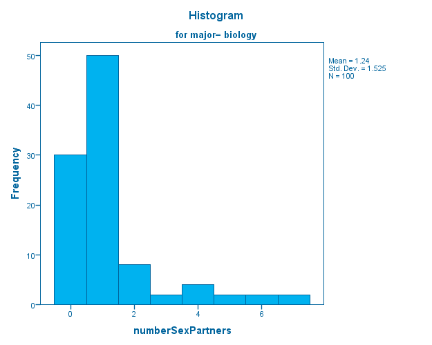

Histograms  
Histograms - major= sports - August 16, 2018

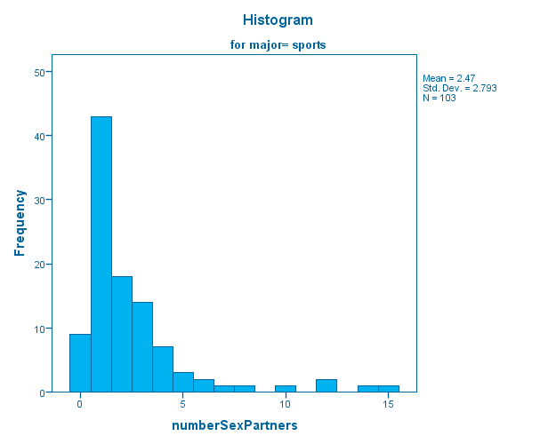

Normal Q-Q Plots  
Normal Q-Q Plots - major= biology - August 16, 2018

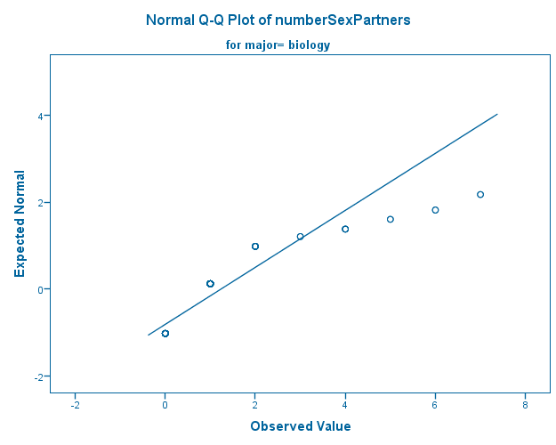

Normal Q-Q Plots  
Normal Q-Q Plots - major= sports - August 16, 2018

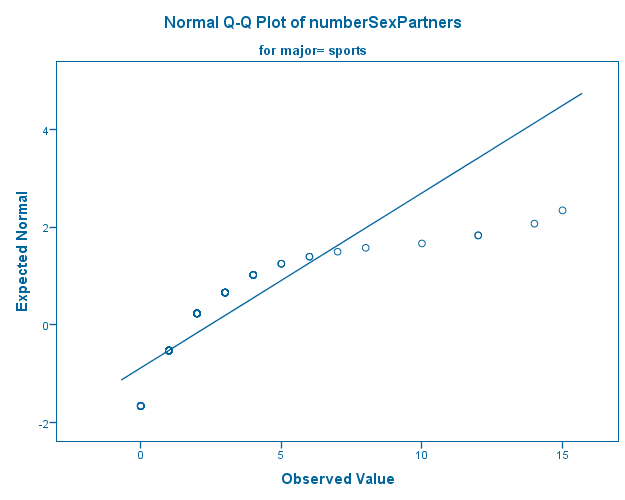

Detrended Normal Q-Q Plots  
Detrended Normal Q-Q Plots - major= biology - August 16, 2018

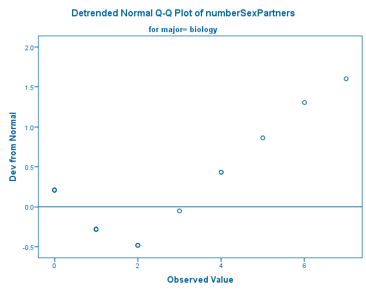

Detrended Normal Q-Q Plots  
Detrended Normal Q-Q Plots - major= sports - August 16, 2018

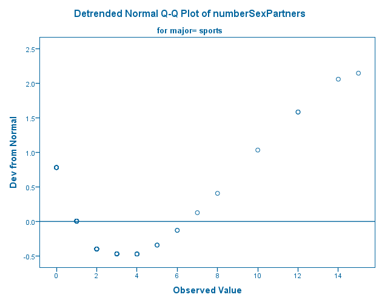

numberSexPartners  
numberSexPartners - Boxplot - August 16, 2018

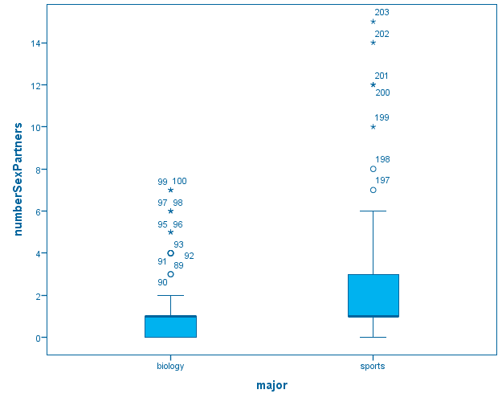

Log  
Log - Log - August 16, 2018

COMPUTE LogTransform=LN(numberSexPartners+1).  
EXECUTE.  
COMPUTE Reciprocal=1/(numberSexPartners+1).  
EXECUTE.  
COMPUTE sqrt=SQRT(numberSexPartners+0.5).  
EXECUTE.  
EXAMINE VARIABLES=numberSexPartners Reciprocal sqrt LogTransform BY major  
/PLOT BOXPLOT HISTOGRAM NPPLOT  
/COMPARE GROUPS  
/STATISTICS DESCRIPTIVES  
/CINTERVAL 95  
/MISSING LISTWISE  
/NOTOTAL.

major  
major - Case Processing Summary - August 16, 2018

Case Processing SummaryCase Processing Summary, table, 3 levels of column headers and 2 levels of row headers, table with 8 columns and 12 rows

|  | major | Cases |  |  |  |  |  |
| --- | --- | --- | --- | --- | --- | --- | --- |
|  |  | Valid |  | Missing |  | Total |  |
|  |  | N | Percent | N | Percent | N | Percent |
| numberSexPartners | biology | 100 | 100.0% | 0 | 0.0% | 100 | 100.0% |
|  | sports | 103 | 100.0% | 0 | 0.0% | 103 | 100.0% |
| Reciprocal | biology | 100 | 100.0% | 0 | 0.0% | 100 | 100.0% |
|  | sports | 103 | 100.0% | 0 | 0.0% | 103 | 100.0% |
| sqrt | biology | 100 | 100.0% | 0 | 0.0% | 100 | 100.0% |
|  | sports | 103 | 100.0% | 0 | 0.0% | 103 | 100.0% |
| LogTransform | biology | 100 | 100.0% | 0 | 0.0% | 100 | 100.0% |
|  | sports | 103 | 100.0% | 0 | 0.0% | 103 | 100.0% |

major  
major - Descriptives - August 16, 2018

DescriptivesDescriptives, table, 1 levels of column headers and 4 levels of row headers, table with 6 columns and 106 rows

|  | major |  |  | Statistic | Std. Error |
| --- | --- | --- | --- | --- | --- |
| numberSexPartners | biology | Mean |  | 1.24 | .153 |
|  |  | 95% Confidence Interval for Mean | Lower Bound | .94 |  |
|  |  |  | Upper Bound | 1.54 |  |
|  |  | 5% Trimmed Mean |  | 1.03 |  |
|  |  | Median |  | 1.00 |  |
|  |  | Variance |  | 2.326 |  |
|  |  | Std. Deviation |  | 1.525 |  |
|  |  | Minimum |  | 0 |  |
|  |  | Maximum |  | 7 |  |
|  |  | Range |  | 7 |  |
|  |  | Interquartile Range |  | 1 |  |
|  |  | Skewness |  | 2.165 | .241 |
|  |  | Kurtosis |  | 4.751 | .478 |
|  | sports | Mean |  | 2.47 | .275 |
|  |  | 95% Confidence Interval for Mean | Lower Bound | 1.92 |  |
|  |  |  | Upper Bound | 3.01 |  |
|  |  | 5% Trimmed Mean |  | 2.05 |  |
|  |  | Median |  | 1.00 |  |
|  |  | Variance |  | 7.800 |  |
|  |  | Std. Deviation |  | 2.793 |  |
|  |  | Minimum |  | 0 |  |
|  |  | Maximum |  | 15 |  |
|  |  | Range |  | 15 |  |
|  |  | Interquartile Range |  | 2 |  |
|  |  | Skewness |  | 2.671 | .238 |
|  |  | Kurtosis |  | 7.931 | .472 |
| Reciprocal | biology | Mean |  | .5984 | .02842 |
|  |  | 95% Confidence Interval for Mean | Lower Bound | .5420 |  |
|  |  |  | Upper Bound | .6548 |  |
|  |  | 5% Trimmed Mean |  | .6015 |  |

[output cut: 74 more lines]

major  
major - Tests of Normality - August 16, 2018

Tests of NormalityTests of Normality, table, 2 levels of column headers and 2 levels of row headers, table with 8 columns and 12 rows

|  | major | Kolmogorov-Smirnov<sup>a</sup> |  |  | Shapiro-Wilk |  |  |
| --- | --- | --- | --- | --- | --- | --- | --- |
|  |  | Statistic | df | Sig. | Statistic | df | Sig. |
| numberSexPartners | biology | .363 | 100 | .000 | .687 | 100 | .000 |
|  | sports | .246 | 103 | .000 | .672 | 103 | .000 |
| Reciprocal | biology | .335 | 100 | .000 | .799 | 100 | .000 |
|  | sports | .268 | 103 | .000 | .833 | 103 | .000 |
| sqrt | biology | .301 | 100 | .000 | .799 | 100 | .000 |
|  | sports | .221 | 103 | .000 | .832 | 103 | .000 |
| LogTransform | biology | .263 | 100 | .000 | .832 | 100 | .000 |
|  | sports | .221 | 103 | .000 | .901 | 103 | .000 |

a. Lilliefors Significance Correction

Histograms  
Histograms - major= biology - August 16, 2018

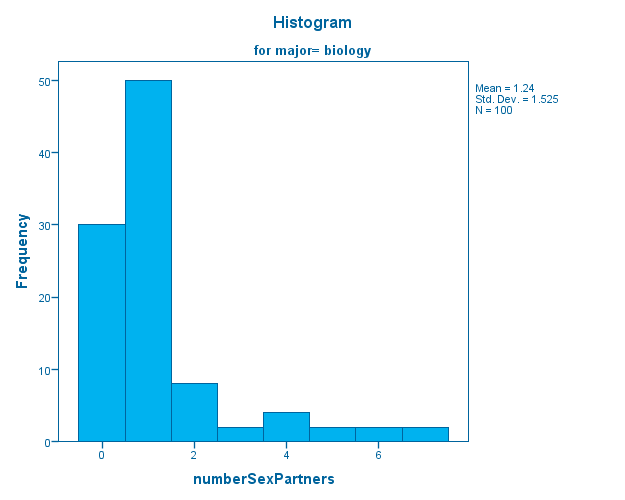

Histograms  
Histograms - major= sports - August 16, 2018

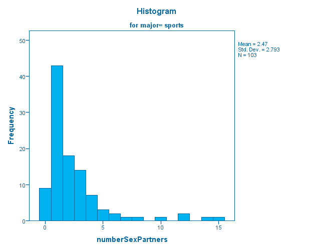

Normal Q-Q Plots  
Normal Q-Q Plots - major= biology - August 16, 2018

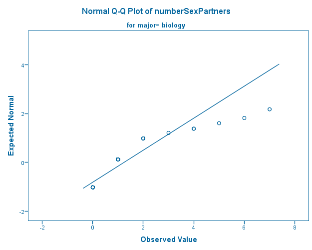

Normal Q-Q Plots  
Normal Q-Q Plots - major= sports - August 16, 2018

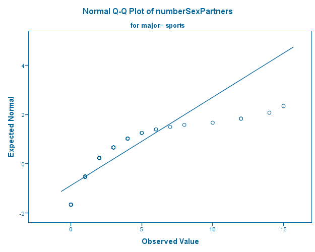

Detrended Normal Q-Q Plots  
Detrended Normal Q-Q Plots - major= biology - August 16, 2018

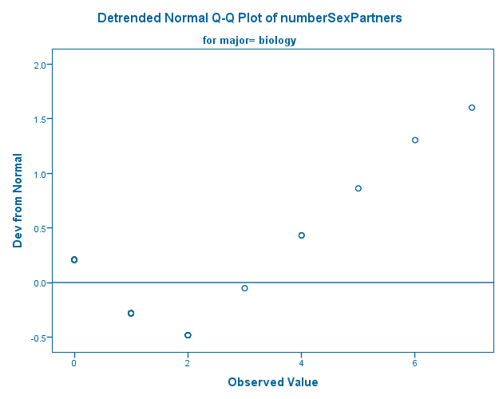

Detrended Normal Q-Q Plots  
Detrended Normal Q-Q Plots - major= sports - August 16, 2018

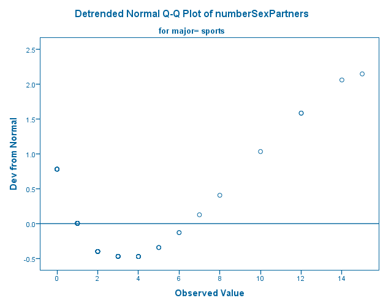

numberSexPartners  
numberSexPartners - Boxplot - August 16, 2018

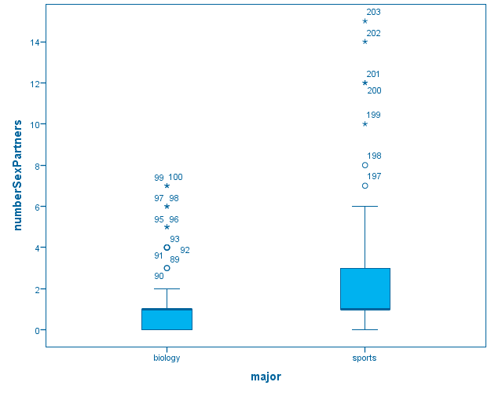

Histograms  
Histograms - major= biology - August 16, 2018

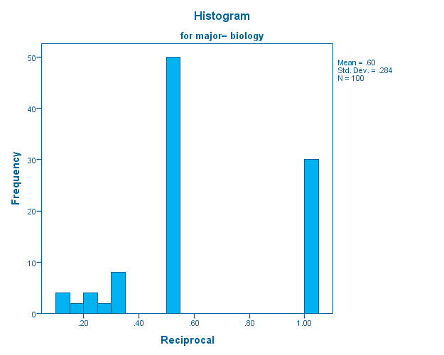

Histograms  
Histograms - major= sports - August 16, 2018

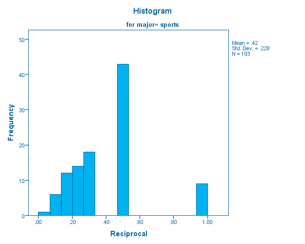

Normal Q-Q Plots  
Normal Q-Q Plots - major= biology - August 16, 2018

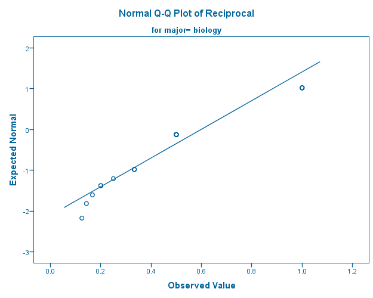

Normal Q-Q Plots  
Normal Q-Q Plots - major= sports - August 16, 2018

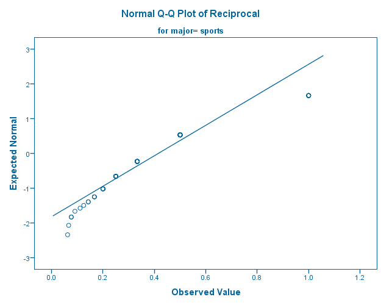

Detrended Normal Q-Q Plots  
Detrended Normal Q-Q Plots - major= biology - August 16, 2018

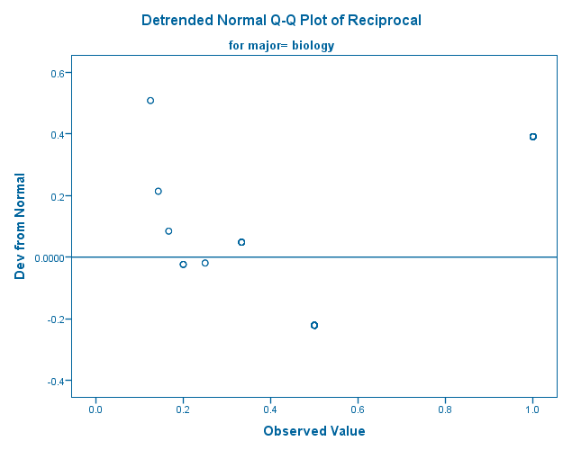

Detrended Normal Q-Q Plots  
Detrended Normal Q-Q Plots - major= sports - August 16, 2018

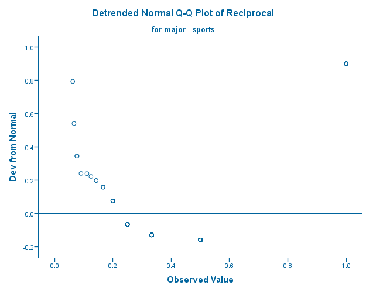

Reciprocal  
Reciprocal - Boxplot - August 16, 2018

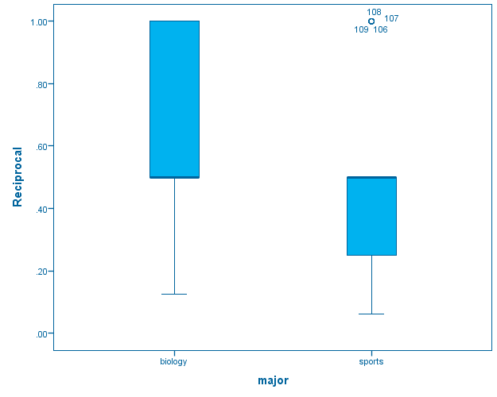

Histograms  
Histograms - major= biology - August 16, 2018

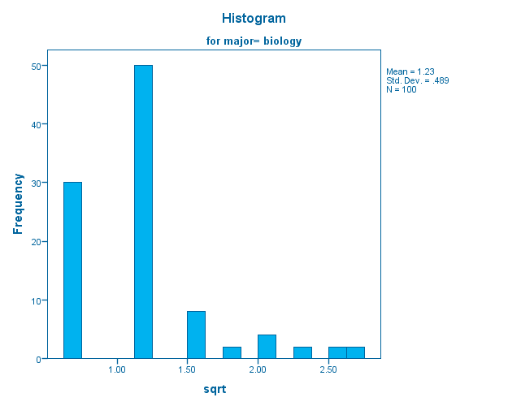

Histograms  
Histograms - major= sports - August 16, 2018

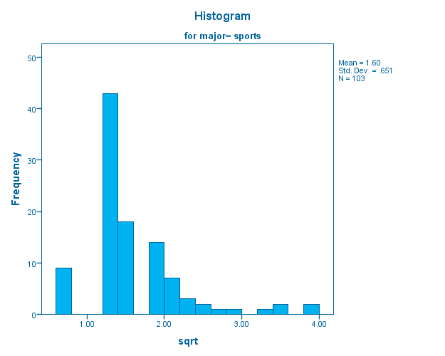

Normal Q-Q Plots  
Normal Q-Q Plots - major= biology - August 16, 2018

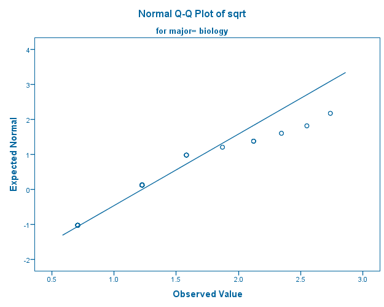

Normal Q-Q Plots  
Normal Q-Q Plots - major= sports - August 16, 2018

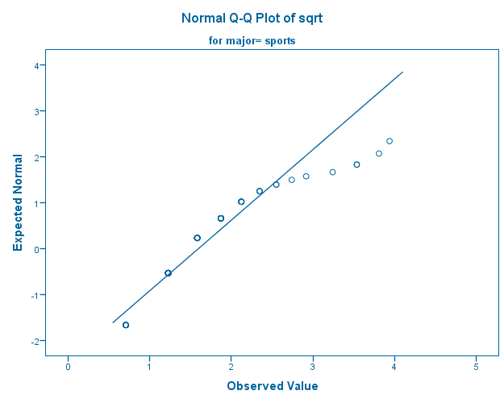

Detrended Normal Q-Q Plots  
Detrended Normal Q-Q Plots - major= biology - August 16, 2018

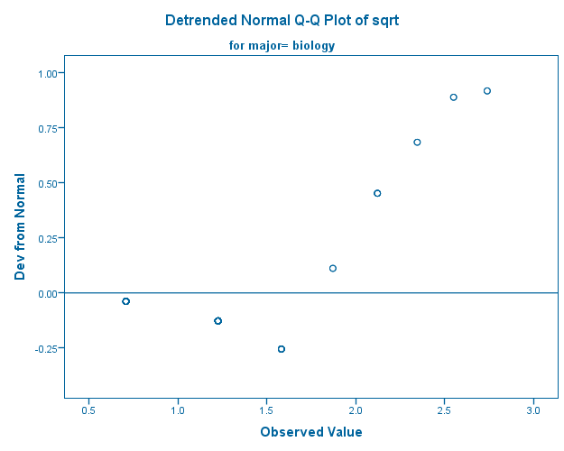

Detrended Normal Q-Q Plots  
Detrended Normal Q-Q Plots - major= sports - August 16, 2018

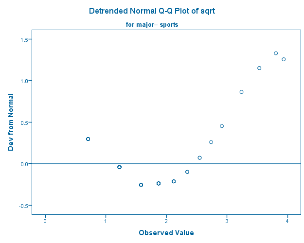

sqrt  
sqrt - Boxplot - August 16, 2018

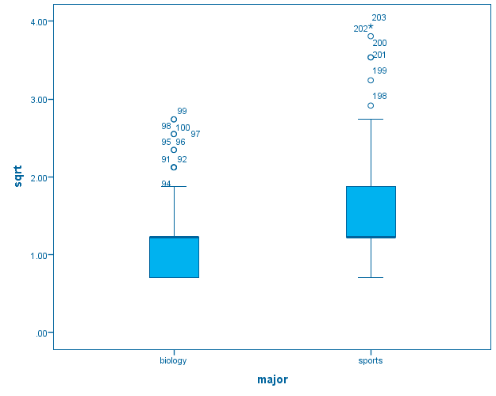

Histograms  
Histograms - major= biology - August 16, 2018

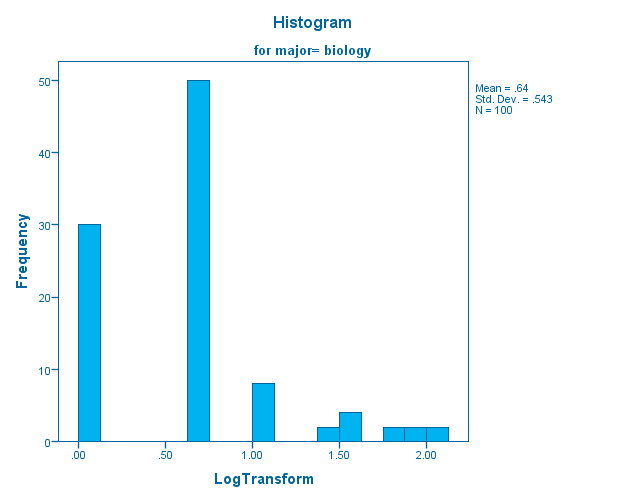

Histograms  
Histograms - major= sports - August 16, 2018

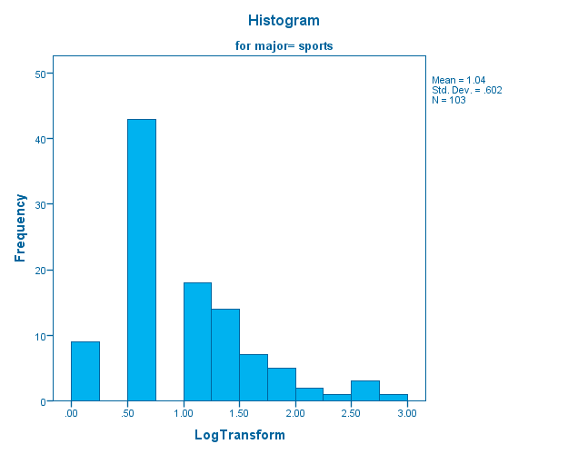

Normal Q-Q Plots  
Normal Q-Q Plots - major= biology - August 16, 2018

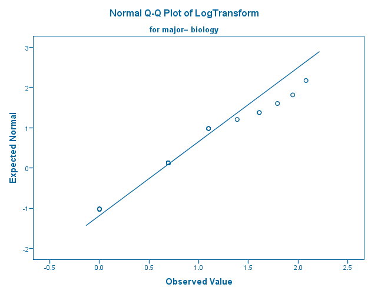

Normal Q-Q Plots  
Normal Q-Q Plots - major= sports - August 16, 2018

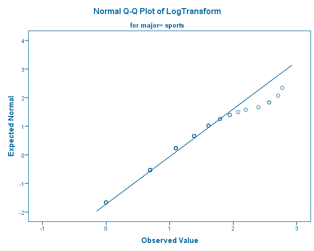

Detrended Normal Q-Q Plots  
Detrended Normal Q-Q Plots - major= biology - August 16, 2018

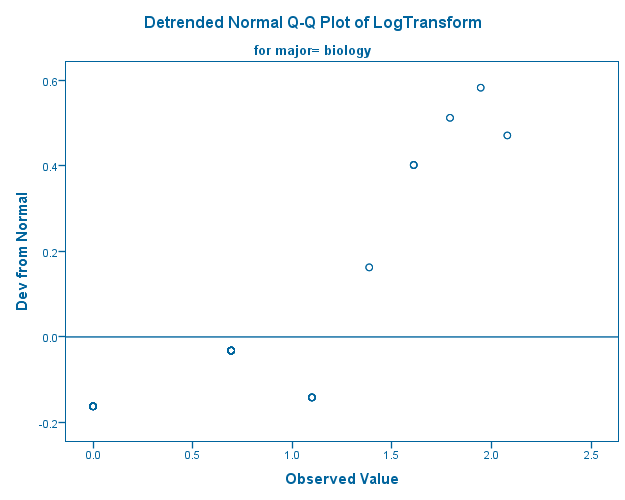

Detrended Normal Q-Q Plots  
Detrended Normal Q-Q Plots - major= sports - August 16, 2018

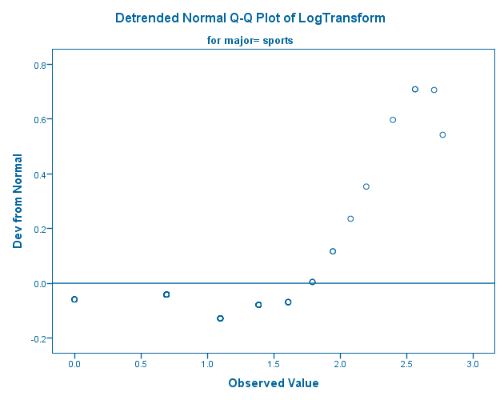

LogTransform  
LogTransform - Boxplot - August 16, 2018

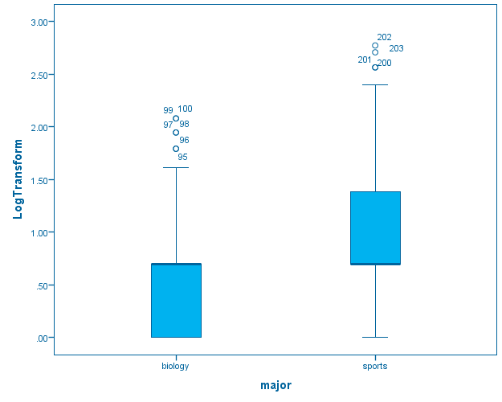

Log  
Log - Log - August 16, 2018

NPAR TESTS  
/M-W= numberSexPartners BY major(0 1)  
/MISSING ANALYSIS.

Mann-Whitney Test  
Mann-Whitney Test - Ranks - August 16, 2018

RanksRanks, table, 1 levels of column headers and 2 levels of row headers, table with 5 columns and 5 rows

|  | major | N | Mean Rank | Sum of Ranks |
| --- | --- | --- | --- | --- |
| numberSexPartners | biology | 100 | 82.70 | 8270.00 |
|  | sports | 103 | 120.74 | 12436.00 |
|  | Total | 203 |  |  |

Mann-Whitney Test  
Mann-Whitney Test - Test Statistics - August 16, 2018

Test Statistics<sup>a</sup>Test Statistics, table, 1 levels of column headers and 1 levels of row headers, table with 2 columns and 7 rows

|  | numberSexPartners |
| --- | --- |
| Mann-Whitney U | 3220.000 |
| Wilcoxon W | 8270.000 |
| Z | -4.878 |
| Asymp. Sig. (2-tailed) | .000 |

a. Grouping Variable: major

Log  
Log - Log - August 16, 2018

GET  
FILE='C:\Users\Heather\OneDrive - Brock University\Masters\TA\BIOL3P96\2019\Lab 7\SPSS files\health expenditure.sav'.  
DATASET NAME DataSet11 WINDOW=FRONT.  
COMPUTE LogTransform=LN(expenditure).  
EXECUTE.

Log  
Log - Log - August 16, 2018

EXAMINE VARIABLES=expenditure LogTransform  
/PLOT BOXPLOT HISTOGRAM NPPLOT  
/COMPARE GROUPS  
/STATISTICS DESCRIPTIVES  
/CINTERVAL 95  
/MISSING LISTWISE  
/NOTOTAL.

Explore  
Explore - Case Processing Summary - August 16, 2018

Case Processing SummaryCase Processing Summary, table, 3 levels of column headers and 1 levels of row headers, table with 7 columns and 6 rows

|  | Cases |  |  |  |  |  |
| --- | --- | --- | --- | --- | --- | --- |
|  | Valid |  | Missing |  | Total |  |
|  | N | Percent | N | Percent | N | Percent |
| expenditure | 20 | 100.0% | 0 | 0.0% | 20 | 100.0% |
| LogTransform | 20 | 100.0% | 0 | 0.0% | 20 | 100.0% |

Explore  
Explore - Descriptives - August 16, 2018

DescriptivesDescriptives, table, 1 levels of column headers and 3 levels of row headers, table with 5 columns and 28 rows

|  |  |  | Statistic | Std. Error |
| --- | --- | --- | --- | --- |
| expenditure | Mean |  | 860.15 | 285.502 |
|  | 95% Confidence Interval for Mean | Lower Bound | 262.59 |  |
|  |  | Upper Bound | 1457.71 |  |
|  | 5% Trimmed Mean |  | 693.78 |  |
|  | Median |  | 340.50 |  |
|  | Variance |  | 1630224.239 |  |
|  | Std. Deviation |  | 1276.802 |  |
|  | Minimum |  | 47 |  |
|  | Maximum |  | 4668 |  |
|  | Range |  | 4621 |  |
|  | Interquartile Range |  | 759 |  |
|  | Skewness |  | 2.320 | .512 |
|  | Kurtosis |  | 4.859 | .992 |
| LogTransform | Mean |  | 5.9101 | .30096 |
|  | 95% Confidence Interval for Mean | Lower Bound | 5.2802 |  |
|  |  | Upper Bound | 6.5400 |  |
|  | 5% Trimmed Mean |  | 5.8835 |  |
|  | Median |  | 5.8286 |  |
|  | Variance |  | 1.812 |  |
|  | Std. Deviation |  | 1.34594 |  |
|  | Minimum |  | 3.85 |  |
|  | Maximum |  | 8.45 |  |
|  | Range |  | 4.60 |  |
|  | Interquartile Range |  | 2.01 |  |
|  | Skewness |  | .282 | .512 |
|  | Kurtosis |  | -.691 | .992 |

Explore  
Explore - Tests of Normality - August 16, 2018

Tests of NormalityTests of Normality, table, 2 levels of column headers and 1 levels of row headers, table with 7 columns and 7 rows

|  | Kolmogorov-Smirnov<sup>a</sup> |  |  | Shapiro-Wilk |  |  |
| --- | --- | --- | --- | --- | --- | --- |
|  | Statistic | df | Sig. | Statistic | df | Sig. |
| expenditure | .293 | 20 | .000 | .646 | 20 | .000 |
| LogTransform | .078 | 20 | .200* | .967 | 20 | .698 |

*. This is a lower bound of the true significance.  
a. Lilliefors Significance Correction

expenditure  
expenditure - Histogram - August 16, 2018

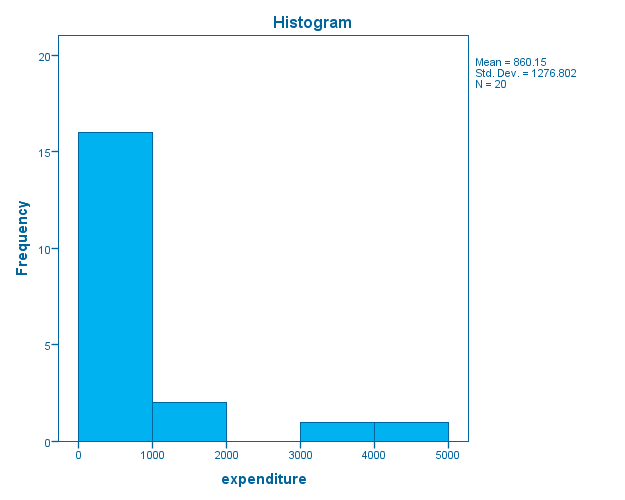

expenditure  
expenditure - Normal Q-Q Plot - August 16, 2018

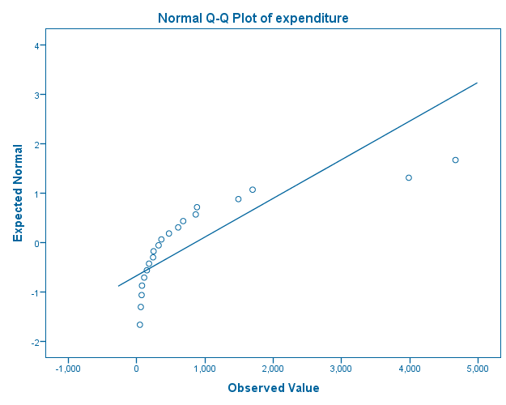

expenditure  
expenditure - Detrended Normal Q-Q Plot - August 16, 2018

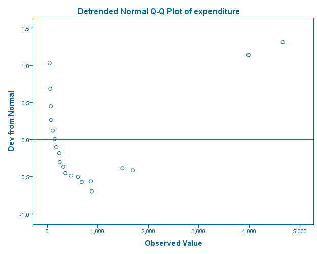

expenditure  
expenditure - Boxplot - August 16, 2018

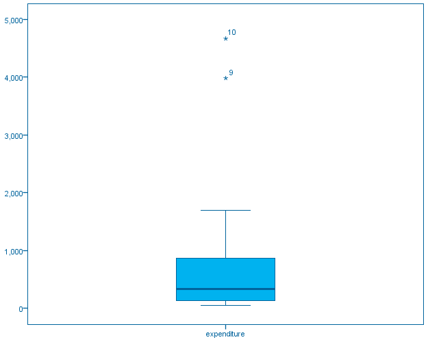

LogTransform  
LogTransform - Histogram - August 16, 2018

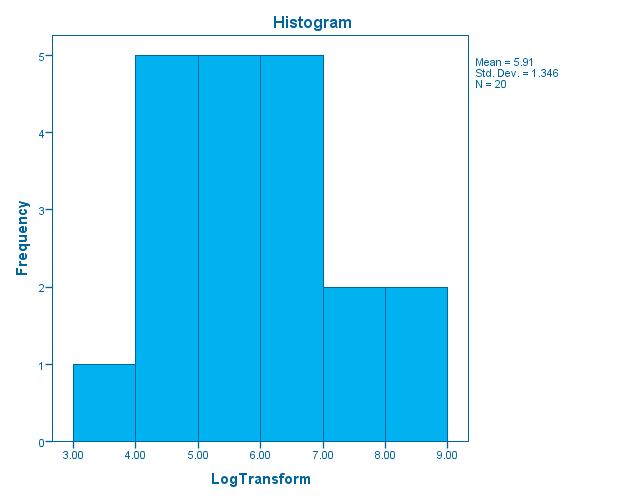

LogTransform  
LogTransform - Normal Q-Q Plot - August 16, 2018

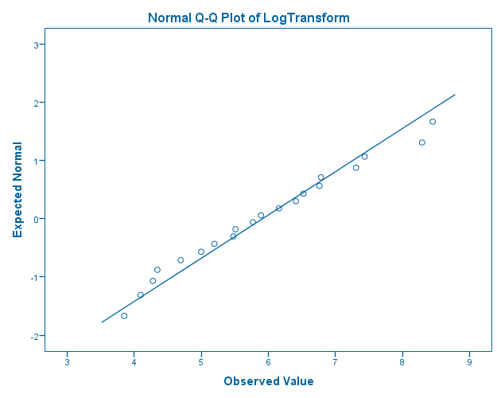

LogTransform  
LogTransform - Detrended Normal Q-Q Plot - August 16, 2018

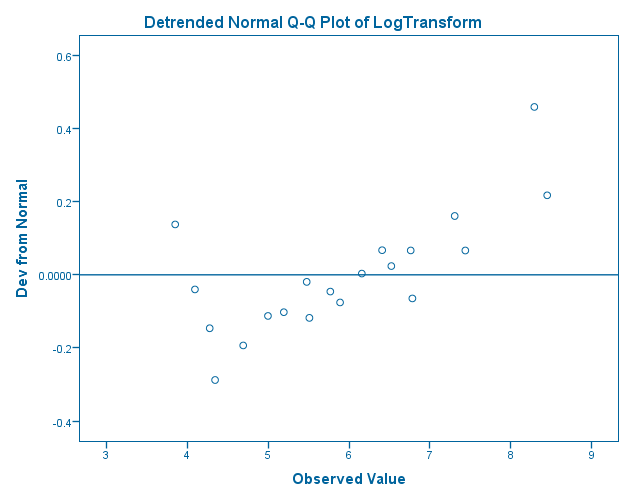

LogTransform  
LogTransform - Boxplot - August 16, 2018

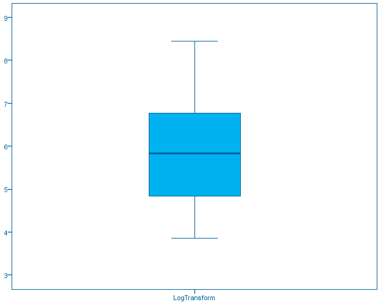

Log  
Log - Log - August 16, 2018

NPar Tests  
NPar Tests - Active Dataset - August 16, 2018

[DataSet12] C:\Users\Heather\OneDrive - Brock University\Masters\TA\BIOL3P96\2019\Lab 7\SPSS files\Lions.sav

Mann-Whitney Test  
Mann-Whitney Test - Ranks - August 16, 2018

RanksRanks, table, 1 levels of column headers and 2 levels of row headers, table with 5 columns and 5 rows

|  | death | N | Mean Rank | Sum of Ranks |
| --- | --- | --- | --- | --- |
| daysToNextCub | Accidental | 9 | 5.67 | 51.00 |
|  | Infanticide | 5 | 10.80 | 54.00 |
|  | Total | 14 |  |  |

Mann-Whitney Test  
Mann-Whitney Test - Test Statistics - August 16, 2018

Test Statistics<sup>a</sup>Test Statistics, table, 1 levels of column headers and 1 levels of row headers, table with 2 columns and 9 rows

|  | daysToNextCub |
| --- | --- |
| Mann-Whitney U | 6.000 |
| Wilcoxon W | 51.000 |
| Z | -2.200 |
| Asymp. Sig. (2-tailed) | .028 |
| Exact Sig. [2*(1-tailed Sig.)] | .029<sup>b</sup> |

a. Grouping Variable: death  
b. Not corrected for ties.

Log  
Log - Log - August 16, 2018

GET  
FILE='C:\Users\Heather\OneDrive - Brock University\Masters\TA\BIOL3P96\2019\Lab 7\SPSS files\Parasitic ducks.sav'.  
DATASET NAME DataSet13 WINDOW=FRONT.  
NPAR TESTS  
/SIGN=Null WITH parasitismFirstIndex (PAIRED)  
/MISSING ANALYSIS.

NPar Tests  
NPar Tests - Active Dataset - August 16, 2018

[DataSet13] C:\Users\Heather\OneDrive - Brock University\Masters\TA\BIOL3P96\2019\Lab 7\SPSS files\Parasitic ducks.sav

Sign Test  
Sign Test - Frequencies - August 16, 2018

FrequenciesFrequencies, table, 1 levels of column headers and 2 levels of row headers, table with 3 columns and 9 rows

|  |  | N |
| --- | --- | --- |
| parasitismFirstIndex - Null | Negative Differences<sup>a</sup> | 1 |
|  | Positive Differences<sup>b</sup> | 12 |
|  | Ties<sup>c</sup> | 1 |
|  | Total | 14 |

a. parasitismFirstIndex < Null  
b. parasitismFirstIndex > Null  
c. parasitismFirstIndex = Null

Sign Test  
Sign Test - Test Statistics - August 16, 2018

Test Statistics<sup>a</sup>Test Statistics, table, 1 levels of column headers and 1 levels of row headers, table with 2 columns and 5 rows

|  | parasitismFirstIndex - Null |
| --- | --- |
| Exact Sig. (2-tailed) | .003<sup>b</sup> |

a. Sign Test  
b. Binomial distribution used.

Log  
Log - Log - August 16, 2018

NPar Tests  
NPar Tests - Active Dataset - August 16, 2018

[DataSet14] C:\Users\Heather\OneDrive - Brock University\Masters\TA\BIOL3P96\2019\Lab 7\SPSS files\Incompatible mates.sav

Sign Test  
Sign Test - Frequencies - August 16, 2018

FrequenciesFrequencies, table, 1 levels of column headers and 2 levels of row headers, table with 3 columns and 9 rows

|  |  | N |
| --- | --- | --- |
| Incompatible - Compatible | Negative Differences<sup>a</sup> | 1 |
|  | Positive Differences<sup>b</sup> | 42 |
|  | Ties<sup>c</sup> | 0 |
|  | Total | 43 |

a. Incompatible < Compatible  
b. Incompatible > Compatible  
c. Incompatible = Compatible

Sign Test  
Sign Test - Test Statistics - August 16, 2018

Test Statistics<sup>a</sup>Test Statistics, table, 1 levels of column headers and 1 levels of row headers, table with 2 columns and 5 rows

|  | Incompatible - Compatible |
| --- | --- |
| Z | -6.100 |
| Asymp. Sig. (2-tailed) | .000 |

a. Sign Test

Log  
Log - Log - August 16, 2018

GET  
FILE='C:\Users\Heather\OneDrive - Brock University\Masters\TA\BIOL3P96\2019\Lab 7\SPSS files\Contraception Prevalence.sav'.  
DATASET NAME DataSet15 WINDOW=FRONT.  
EXAMINE VARIABLES=YR2002 YR2012  
/PLOT BOXPLOT HISTOGRAM NPPLOT  
/COMPARE GROUPS  
/STATISTICS DESCRIPTIVES  
/CINTERVAL 95  
/MISSING LISTWISE  
/NOTOTAL.

Explore  
Explore - Active Dataset - August 16, 2018

[DataSet15] C:\Users\Heather\OneDrive - Brock University\Masters\TA\BIOL3P96\2019\Lab 7\SPSS files\Contraception Prevalence.sav

Explore  
Explore - Case Processing Summary - August 16, 2018

Case Processing SummaryCase Processing Summary, table, 3 levels of column headers and 1 levels of row headers, table with 7 columns and 6 rows

|  | Cases |  |  |  |  |  |
| --- | --- | --- | --- | --- | --- | --- |
|  | Valid |  | Missing |  | Total |  |
|  | N | Percent | N | Percent | N | Percent |
| YR2002 | 57 | 100.0% | 0 | 0.0% | 57 | 100.0% |
| YR2012 | 57 | 100.0% | 0 | 0.0% | 57 | 100.0% |

Explore  
Explore - Descriptives - August 16, 2018

DescriptivesDescriptives, table, 1 levels of column headers and 3 levels of row headers, table with 5 columns and 28 rows

|  |  |  | Statistic | Std. Error |
| --- | --- | --- | --- | --- |
| YR2002 | Mean |  | 40.5795 | 3.21337 |
|  | 95% Confidence Interval for Mean | Lower Bound | 34.1424 |  |
|  |  | Upper Bound | 47.0167 |  |
|  | 5% Trimmed Mean |  | 40.3462 |  |
|  | Median |  | 40.9667 |  |
|  | Variance |  | 588.566 |  |
|  | Std. Deviation |  | 24.26037 |  |
|  | Minimum |  | 4.30 |  |
|  | Maximum |  | 84.38 |  |
|  | Range |  | 80.08 |  |
|  | Interquartile Range |  | 44.38 |  |
|  | Skewness |  | .039 | .316 |
|  | Kurtosis |  | -1.348 | .623 |
| YR2012 | Mean |  | 44.7142 | 3.06248 |
|  | 95% Confidence Interval for Mean | Lower Bound | 38.5793 |  |
|  |  | Upper Bound | 50.8490 |  |
|  | 5% Trimmed Mean |  | 44.5573 |  |
|  | Median |  | 49.0000 |  |
|  | Variance |  | 534.590 |  |
|  | Std. Deviation |  | 23.12120 |  |
|  | Minimum |  | 5.60 |  |
|  | Maximum |  | 88.25 |  |
|  | Range |  | 82.65 |  |
|  | Interquartile Range |  | 41.40 |  |
|  | Skewness |  | .045 | .316 |
|  | Kurtosis |  | -1.265 | .623 |

Explore  
Explore - Tests of Normality - August 16, 2018

Tests of NormalityTests of Normality, table, 2 levels of column headers and 1 levels of row headers, table with 7 columns and 7 rows

|  | Kolmogorov-Smirnov<sup>a</sup> |  |  | Shapiro-Wilk |  |  |
| --- | --- | --- | --- | --- | --- | --- |
|  | Statistic | df | Sig. | Statistic | df | Sig. |
| YR2002 | .101 | 57 | .200* | .936 | 57 | .005 |
| YR2012 | .109 | 57 | .092 | .945 | 57 | .011 |

*. This is a lower bound of the true significance.  
a. Lilliefors Significance Correction

YR2002  
YR2002 - Histogram - August 16, 2018

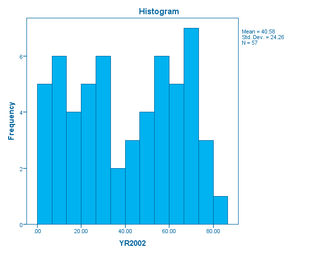

YR2002  
YR2002 - Normal Q-Q Plot - August 16, 2018

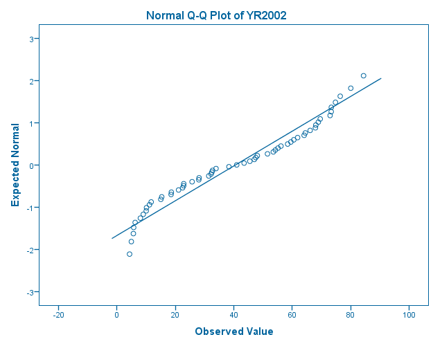

YR2002  
YR2002 - Detrended Normal Q-Q Plot - August 16, 2018

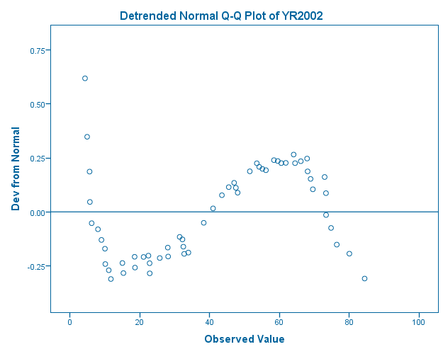

YR2002  
YR2002 - Boxplot - August 16, 2018

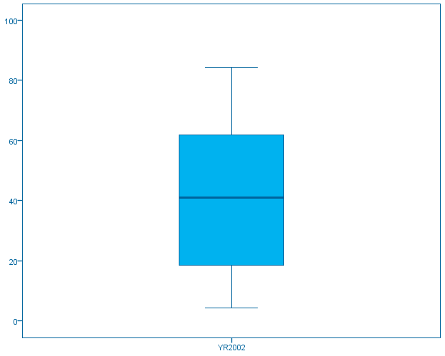

YR2012  
YR2012 - Histogram - August 16, 2018

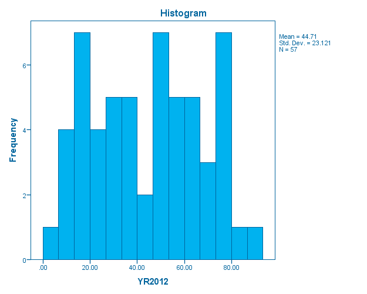

YR2012  
YR2012 - Normal Q-Q Plot - August 16, 2018

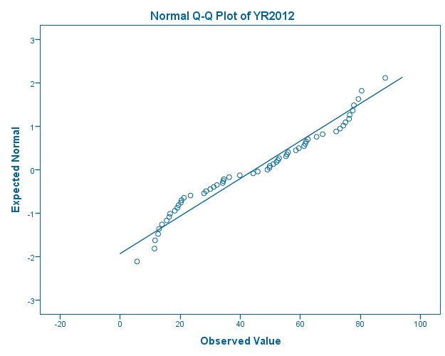

YR2012  
YR2012 - Detrended Normal Q-Q Plot - August 16, 2018

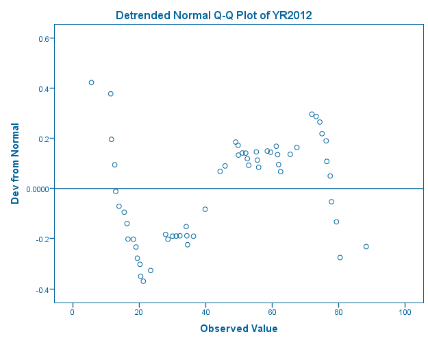

YR2012  
YR2012 - Boxplot - August 16, 2018

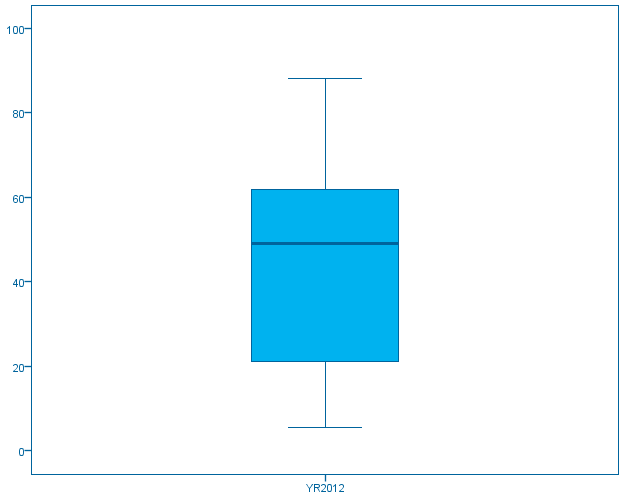

Log  
Log - Log - August 16, 2018

NPAR TESTS  
/SIGN=YR2002 WITH YR2012 (PAIRED)  
/MISSING ANALYSIS.

Sign Test  
Sign Test - Frequencies - August 16, 2018

FrequenciesFrequencies, table, 1 levels of column headers and 2 levels of row headers, table with 3 columns and 9 rows

|  |  | N |
| --- | --- | --- |
| YR2012 - YR2002 | Negative Differences<sup>a</sup> | 15 |
|  | Positive Differences<sup>b</sup> | 42 |
|  | Ties<sup>c</sup> | 0 |
|  | Total | 57 |

a. YR2012 < YR2002  
b. YR2012 > YR2002  
c. YR2012 = YR2002

Sign Test  
Sign Test - Test Statistics - August 16, 2018

Test Statistics<sup>a</sup>Test Statistics, table, 1 levels of column headers and 1 levels of row headers, table with 2 columns and 5 rows

|  | YR2012 - YR2002 |
| --- | --- |
| Z | -3.444 |
| Asymp. Sig. (2-tailed) | .001 |

a. Sign Test

[output not shown]

[output not shown]

[output not shown]

[output not shown]

[output not shown]

[output not shown]